# Reproducible Research: Peer Assessment 1

## Step 1. Loading and preprocessing the data

The variables included in research dataset are:

- **steps**: Number of steps taking in a 5-minute interval (missing values are coded as NA)
- **date**: The date on which the measurement was taken in YYYY-MM-DD format
- **interval**: Identifier for the 5-minute interval in which measurement was taken

The dataset is stored in a comma-separated-value (CSV) file (activity.csv) and there are a total of 17,568 observations in this dataset. CSV file is packed as zip. The following code unpacks the file in data folder and loads in “data” variable.

```r
  if (!file.exists("./data")) {
    dir.create("./data");
  }
  if (!file.exists("./data/activity.csv")) {
    unzip("activity.zip", exdir = "data");
  }
  data <- read.csv("./data/activity.csv")
```

Number of rows loaded:

```
## [1] 17568
```

## Step 2. What is mean total number of steps taken per day?

The following code calculates total number if steps per each day

```r
  stepsPerDay <- aggregate(. ~ date, data = data, sum)
  stepsPerDay[, c("date", "steps")]
```

```
##          date steps
## 1  2012-10-02   126
## 2  2012-10-03 11352
## 3  2012-10-04 12116
## 4  2012-10-05 13294
## 5  2012-10-06 15420
## 6  2012-10-07 11015
## 7  2012-10-09 12811
## 8  2012-10-10  9900
## 9  2012-10-11 10304
## 10 2012-10-12 17382
## 11 2012-10-13 12426
## 12 2012-10-14 15098
## 13 2012-10-15 10139
## 14 2012-10-16 15084
```

[output cut: 39 more lines]

The disribution of number of steps is represented by the following histogram:

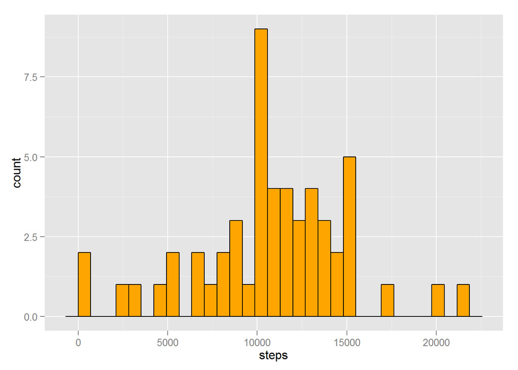

```r
  library(ggplot2)
  ggplot(stepsPerDay, aes(x=steps)) +
    geom_histogram(colour="black", fill="orange")
```

Mean and Median of steps per day are the following

```r
  mean(stepsPerDay$steps)
```

```
## [1] 10766.19
```

```r
  median(stepsPerDay$steps)
```

```
## [1] 10765
```

## Step 3. What is the average daily activity pattern?

Let’s calculate averages of steps for each time interval over all dates:

```r
  intraday <- aggregate(. ~ interval, data= data, mean)[,c("interval", "steps")]
```

The following graph shows distribution of number of steps over the day

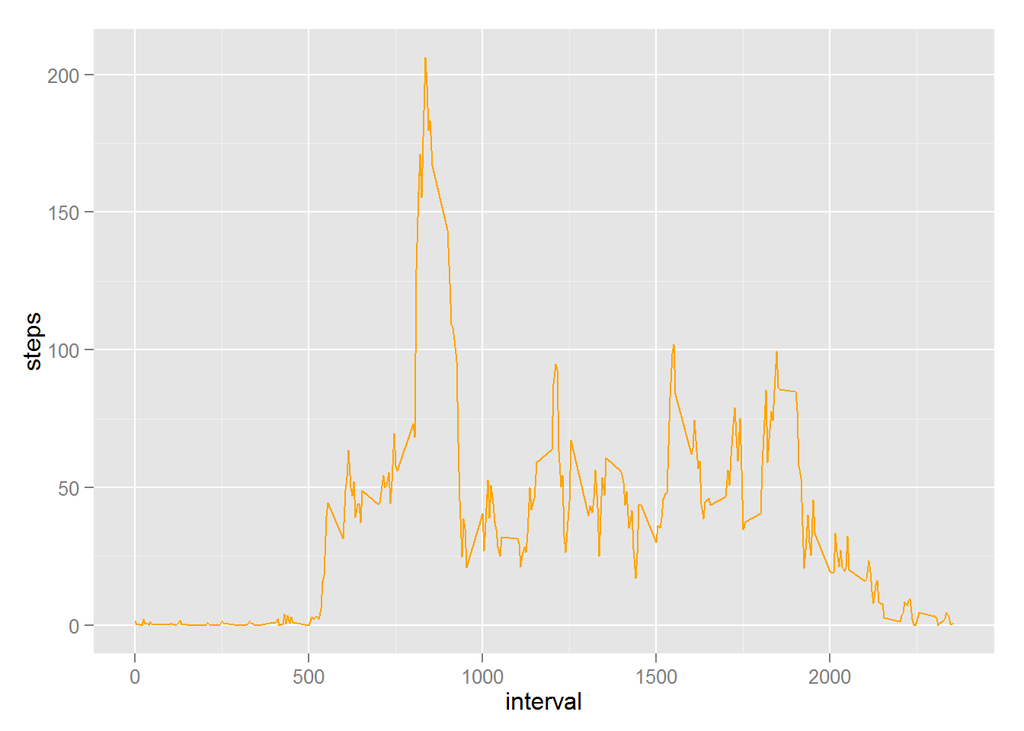

```r
  ggplot(intraday, aes(x=interval, y=steps)) + geom_line(colour="orange")
```

Maximum number of steps is reached in the following 5-minute interval:

```r
  intraday[max(intraday$steps) == intraday$steps, "interval"]
```

```
## [1] 835
```

## Imputing missing values

Number of lines with NA:

```r
sum(is.na(data$steps))
```

```
## [1] 2304
```

Let’s fill missing values with average of steps for same 5-minute intervals on other day. We will reuse intraday dataset created previously

```r
  fulldata <- merge(x=data, y=intraday, by="interval", all.x = TRUE)
  fulldata[is.na(fulldata$steps.x),"steps.x"] <- fulldata[is.na(fulldata$steps.x),"steps.y"]
```

Next we aggregate imputed data by day

```r
  stepsPerDayFull <- aggregate(. ~ date, data = fulldata, sum)[, c("date", "steps.x")]
```

The disribution of number of steps with imputed data is represented by the following histogram:

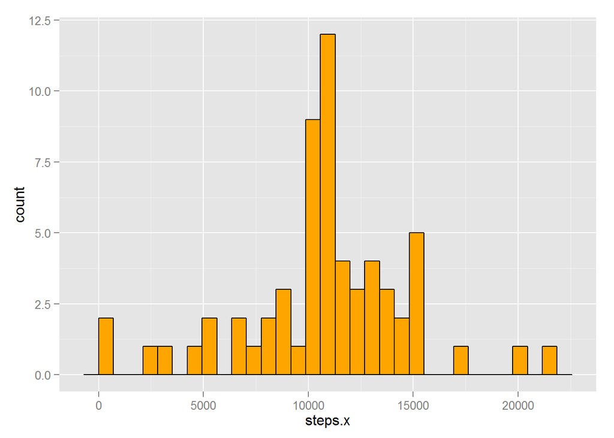

```r
  ggplot(stepsPerDayFull, aes(x=steps.x)) +
    geom_histogram(colour="black", fill="orange")
```

Mean and Median of steps per day is the following are the following

```r
  mean(stepsPerDayFull$steps.x)
```

```
## [1] 10766.19
```

```r
  median(stepsPerDayFull$steps.x)
```

```
## [1] 10766.19
```

## Are there differences in activity patterns between weekdays and weekends?

Let’s fill wday xolumn with weekday/weekend factor

```r
fulldata$wday <- factor(ifelse(weekdays(as.Date(fulldata$date)) %in% c("Saturday", "Sunday"), "weekend", "weekday"))
```

Now lets average data by 5-minutes intervals

```r
intradayWithDays <- aggregate(steps.x ~ wday + interval, data = fulldata, mean)
```

And display result as graphs

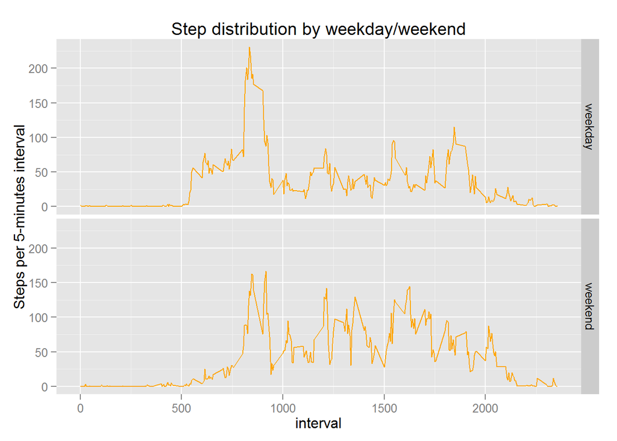

```r
ggplot(intradayWithDays, aes(x=interval, y=steps.x)) +
    geom_line(colour="orange") +
    facet_grid(wday ~ .) +
    ylab("Steps per 5-minutes interval") +
    ggtitle("Step distribution by weekday/weekend")
```